# NICU Discharge Predictions

Leah Carr

### Overview

Predicting time to discharge in neonatal patient care is complex, but essential as neonatal intensive care units (NICUs) need to anticipate unit census for patient admission and staffing purposes and to ensure safe and effective patient transitions to home. As a component of a patient safety and quality improvement (QI) initiative in the CHOP NICU, a checklist was implemented that uses provider-endorsed time windows to aid in discharge predictions. This project explores provider predictive accuracy and factors that might contribute to individuals who discharge at times outside their predicted window.

### Introduction

In the NICU, the youngest hospital patients receive complex care. With nearly 10% of infants in the United States being born premature and a subset of term infants requiring assistance, NICUs provide essential care to a vulnerable patient population. Thanksfully, since the first NICU in the US opened, infant mortality has drastically decreased and many more patients admitted to the NICU are able to be discharged. Anticipation of discharge is key to patient-specific and unit-wide planning. As NICU patients prepare to leave the unit, plans are set in place for medical and supportive care. An anticipated discharge timeframe allows for medications to be prepped, homecare supplies to be delivered, and for families to mentally prepare to take their infants home. Incorrect predictions can lead to delays in discharge, which are not only disappointing, but can have significant implications beyond individual patients. For referral centers, units often admit patients needing coordinated, high-level care or those coming in post-operatively from elective procedures. For these units, discharge timeframes inform whether or not they will have bed space available for admissions. In addition, discharge anticipation is also needed for staff scheduling. While there is a body of literature examining NICU provider predictions of patient mortality, there is limited information regarding provider’s perceptions of time to discharge.

The importance of anticipating discharge timing is not unique to the field of neonatology. Principles and findings from this exploratory analysis can be applied across hospital units that seek to better understand their discharge practices. All hospitals are interested in better understanding what contributes to their ability to admit and discharge patients, whether for patient care and safety purposes or as a component of their business models. Through discussions with Dr. Nicolas Bamat, a neonatal clinical researcher, I was able to better define my demographic characteristics and potential factors influencing discharge. I then connected with two CHOP data analysts, Matt Devine and Jake Riley, who aided in data extraction and analytic planning.

Using data collected from a CHOP NICU QI and safety rounding tool as well as electronic health record (EHR) data taken from EPIC, I aim to evaluate the quality of NICU providers’ abilities to predict discharge and to further assess what factors contribute to incorrect assessments. The discharge-specific component of the tool is currently used as a trigger for multiple aspects of discharge planning, but data regarding its accuracy have yet to be analyzed.

### Methods

Data was obtained through a SQL query of the CHOP Clinical Data Warehouse. The specific data pulled included responses to a weekly question to NICU providers asking them when they anticipate that a patient will discharge. Data was taken from October, 2019 through the end of October, 2020. Providers respond to this question by clicking a button in the EHR with “today,” “<3 days,” “3-7 days,” “7-14 days,” or “no date identified” as potential answer choices. In addition to the actual discharge prediction, the timing of the discharge prediction, and when a patient actually discharged, the query included identifiers (pat_key, visit_key), demographics (gestational age, corrected gestational age, sex, race, ethnicity), patient characteristics (insurance carrier, government vs. commercial insurance categorization, primary and secondary hospital diagnoses and associated ICD-10 codes, presence of a central line [0 - no central line, 1 - central line placed after the question was asked, 2 - central line present at the time the question was asked], presence of an endotracheal tube [numerical coding is the same as with central lines], and whether or not the patient was on IV medications or fluids [again, coding was the same]). In addition, information regarding the accuracy of discharge prediction (0 - inaccurate, 1 - accurate) was pulled.

The data was then opened in R Studio where it was deidentified, cleaned, and then analyzed. The deidentification process involved removal of the pat_key, substitution of values for the visit_key, and removal of all dates instead favoring use of relative values (e.g. time off from anticipated discharge window).

Next, the data was manipulated to examine rates of accuracy across all entries, then accuracy across first prediction vs. last prediction (prediction closest to the time of discharge). Then, bivariate analysis was completed to examine what factors contributed to prediction accuracy. The most significant mediators were then used in logistic regression to further characterize relationships between accuracy and our predictors. Linear regression was then used to further examine factors contributing to the degree of provider inaccuracy. Specifics regarding the code are shown below:

The initial data analysis involved deidentifying the information from a “base” dataset with some cleaning to add columns based off of the timing of discharge using the code featured below.

```r
#pull in necessary packages
library(tidyverse)
library(lubridate)
#pull in data
base_data <- read.csv("ccq_discharge_predictions.csv") %>% #pull in file, rename dataframe as "base_data"
  rename_all(tolower) %>% #format all variables to lowercase
  mutate(
    prediction_entry_date = mdy(prediction_entry_date), #modify date formatting
    discharge_calendar_date = as.Date(mdy_hm(discharge_calendar_date)),
    discharge_prediction_lower_bound = as.Date(mdy(discharge_prediction_lower_bound)),
    discharge_prediction_upper_bound = as.Date(mdy(discharge_prediction_upper_bound))
  )

head(base_data)
```

```
##    pat_key visit_key deceased_ind prediction_entry_date prediction_recorded_timestamp discharge_calendar_date discharge_prediction days_until_discharge discharge_prediction_lower_bound discharge_prediction_upper_bound accurate_prediction_ind actual_age_in_days_at_prediction gestational_age_comple…
## 1 11186018 119161819            0            2019-10-31              10/31/2019 10:17              2020-03-10     no date identied                  131                             <NA>                             <NA>                      NA                              282                       …
## 2 11186018 119161819            0            2019-11-07               11/7/2019 10:06              2020-03-10     no date identied                  124                             <NA>                             <NA>                      NA                              289                       …
## 3 11191863 121896865            0            2019-10-31              10/31/2019 10:44              2020-06-16     no date identied                  229                             <NA>                             <NA>                      NA                              315                       …
## 4 11191863 121896865            0            2019-11-07                11/7/2019 8:53              2020-06-16     no date identied                  222                             <NA>                             <NA>                      NA                              322                       …
## 5 11191863 121896865            0            2019-11-14              11/14/2019 10:23              2020-06-16     no date identied                  215                             <NA>                             <NA>                      NA                              329                       …
## 6 11191863 121896865            0            2019-11-21              11/21/2019 10:22              2020-06-16     no date identied                  208                             <NA>                             <NA>                      NA                              336                       …
##                        race              ethnicity payor_name payor_group respiratory_support_type respiratory_support_category                   primary_hsp_account_dx_name primary_hsp_account_dx_icd10                                                           secondary_dx secondary_dx_icd10 cent…
## 1                     White Not Hispanic Or Latino     OXFORD  COMMERCIAL             non-invasive                          PCV Single liveborn infant, delivered by cesarean                       Z38.01                            Congenital hypoplasia and dysplasia of lung              Q33.6     …
## 2                     White Not Hispanic Or Latino     OXFORD  COMMERCIAL             non-invasive                          PCV Single liveborn infant, delivered by cesarean                       Z38.01                            Congenital hypoplasia and dysplasia of lung              Q33.6     …
## 3 Black or African American Not Hispanic Or Latino  AETNA POS  COMMERCIAL                 invasive                         CONV           Pulmonary hypertension, unspecified                       I27.20 Other chronic respiratory diseases originating in the perinatal period              P27.8     …
## 4 Black or African American Not Hispanic Or Latino  AETNA POS  COMMERCIAL                 invasive                         CONV           Pulmonary hypertension, unspecified                       I27.20 Other chronic respiratory diseases originating in the perinatal period              P27.8     …
## 5 Black or African American Not Hispanic Or Latino  AETNA POS  COMMERCIAL                 invasive                         CONV           Pulmonary hypertension, unspecified                       I27.20 Other chronic respiratory diseases originating in the perinatal period              P27.8     …
## 6 Black or African American Not Hispanic Or Latino  AETNA POS  COMMERCIAL                 invasive                         CONV           Pulmonary hypertension, unspecified                       I27.20 Other chronic respiratory diseases originating in the perinatal period              P27.8     …
```

```r
str(base_data)
```

```
## 'data.frame':    3854 obs. of  29 variables:
##  $ pat_key                              : int  11186018 11186018 11191863 11191863 11191863 11191863 11191863 11191863 11204375 11204375 ...
##  $ visit_key                            : int  119161819 119161819 121896865 121896865 121896865 121896865 121896865 121896865 119963427 119963427 ...
##  $ deceased_ind                         : int  0 0 0 0 0 0 0 0 0 0 ...
##  $ prediction_entry_date                : Date, format: "2019-10-31" "2019-11-07" "2019-10-31" "2019-11-07" ...
##  $ prediction_recorded_timestamp        : chr  "10/31/2019 10:17" "11/7/2019 10:06" "10/31/2019 10:44" "11/7/2019 8:53" ...
##  $ discharge_calendar_date              : Date, format: "2020-03-10" "2020-03-10" "2020-06-16" "2020-06-16" ...
##  $ discharge_prediction                 : chr  "no date identied" "no date identied" "no date identied" "no date identied" ...
##  $ days_until_discharge                 : int  131 124 229 222 215 208 194 187 61 47 ...
##  $ discharge_prediction_lower_bound     : Date, format: NA NA NA NA ...
##  $ discharge_prediction_upper_bound     : Date, format: NA NA NA NA ...
##  $ accurate_prediction_ind              : int  NA NA NA NA NA NA NA NA NA NA ...
##  $ actual_age_in_days_at_prediction     : int  282 289 315 322 329 336 350 357 178 192 ...
##  $ gestational_age_complete_weeks       : int  37 37 27 27 27 27 27 27 38 38 ...
##  $ gestational_age_remainder_days       : int  3 3 2 2 2 2 2 2 4 4 ...
##  $ corrected_age_in_wks_at_prediction   : num  40.3 41.3 32.3 33.3 34.3 ...
##  $ sex                                  : chr  "F" "F" "F" "F" ...
##  $ race                                 : chr  "White" "White" "Black or African American" "Black or African American" ...
##  $ ethnicity                            : chr  "Not Hispanic Or Latino" "Not Hispanic Or Latino" "Not Hispanic Or Latino" "Not Hispanic Or Latino" ...
##  $ payor_name                           : chr  "OXFORD" "OXFORD" "AETNA POS" "AETNA POS" ...
##  $ payor_group                          : chr  "COMMERCIAL" "COMMERCIAL" "COMMERCIAL" "COMMERCIAL" ...
##  $ respiratory_support_type             : chr  "non-invasive" "non-invasive" "invasive" "invasive" ...
##  $ respiratory_support_category         : chr  "PCV" "PCV" "CONV" "CONV" ...
##  $ primary_hsp_account_dx_name          : chr  "Single liveborn infant, delivered by cesarean" "Single liveborn infant, delivered by cesarean" "Pulmonary hypertension, unspecified" "Pulmonary hypertension, unspecified" ...
##  $ primary_hsp_account_dx_icd10         : chr  "Z38.01" "Z38.01" "I27.20" "I27.20" ...
##  $ secondary_dx                         : chr  "Congenital hypoplasia and dysplasia of lung" "Congenital hypoplasia and dysplasia of lung" "Other chronic respiratory diseases originating in the perinatal period" "Other chronic respiratory diseases originating in the perinatal period" ...
##  $ secondary_dx_icd10                   : chr  "Q33.6" "Q33.6" "P27.8" "P27.8" ...
##  $ central_line_status                  : int  0 0 2 2 2 2 2 2 0 0 ...
##  $ ett_status                           : int  0 0 2 2 2 2 0 0 0 0 ...
##  $ iv_fluid_or_med_start_post_prediction: int  0 0 1 1 1 1 1 1 0 1 ...
```

```r
count(base_data, pat_key) #note there are 854 pat keys
```

```
##      pat_key  n
## 1   11186018  2
## 2   11191863  6
## 3   11204375  5
## 4   11215616 14
## 5   11216472  4
## 6   11221020  2
## 7   11222324 31
## 8   11244690  3
## 9   11250562  1
## 10  11250831  1
## 11  11253347 23
## 12  11253668  4
## 13  11256293  5
## 14  11257088  1
```

[output cut: 840 more lines]

```r
count(base_data, visit_key) #note there are 875 visit keys
```

```
##     visit_key  n
## 1   119161819  2
## 2   119963427  5
## 3   120469987 14
## 4   120515550  4
## 5   120786753 31
## 6   121896865  6
## 7   122182434  1
## 8   122292049 23
## 9   122433064  5
## 10  122506527  1
## 11  122628777  1
## 12  122660084 15
## 13  122898265  1
## 14  122985724 23
```

[output cut: 861 more lines]

```r
anon_data <- base_data %>%
   mutate(
     diff = case_when(
    discharge_calendar_date < discharge_prediction_lower_bound ~ discharge_calendar_date - discharge_prediction_lower_bound,
    discharge_calendar_date <= discharge_prediction_upper_bound ~ 0,
    TRUE ~ discharge_calendar_date - discharge_prediction_upper_bound)
    ) %>% #make a new column looking at how off we are from the predicted time window
    mutate(visit_key = dense_rank(visit_key)) %>%  #for deidentification, modification of the visit keys to random numbers
  group_by(visit_key) %>%
  mutate(est_number = rank(prediction_entry_date)) %>% #make a new column that ranks the number of estimates by prediction entry date for later use
  ungroup() %>%
  select(-c(pat_key, prediction_entry_date, prediction_recorded_timestamp, discharge_calendar_date, discharge_prediction_lower_bound, discharge_prediction_upper_bound, payor_name, corrected_age_in_wks_at_prediction, ethnicity)) #remove unnecessary columns for future analysis and to maintain anonymity

write_csv(anon_data, 'carr_anon_data.csv')
```

The deidentified data can then be loaded for additional cleaning using the code as featured below.

```r
#pull in deidentified data for further cleaning
clean_data <- read.csv("carr_anon_data.csv") %>%
  mutate(discharge_prediction = str_replace_all(discharge_prediction, "no date identied", "no date identified")) %>% #typo noted in some of the data, corrected using stringr
  rename(dx1_name = primary_hsp_account_dx_name) %>% #rename columns to make it easier for data manipulation later on
  rename(dx1_icd10 = primary_hsp_account_dx_icd10) %>%
  rename(dx2_name = secondary_dx) %>%
  rename(dx2_icd10 = secondary_dx_icd10) %>%
  filter(deceased_ind == 0) %>% #remove individuals who did not survive
  mutate(gest_age_groups = cut(gestational_age_complete_weeks, breaks=c(-Inf, 25, 30, 35, Inf), labels=c("<25 weeks","25-30 weeks","30-35 weeks", ">35 weeks"))) %>% #categorize gestational age for further analysis
  filter(gest_age_groups != "NA") %>% #remove NA gest age values
  filter(sex != "U") #remove unidentifed sex values
```

Examination of overall accuracy of predictions.

```r
#make a dataframe looking at how providers anticipated discharge
pred_descrip <- clean_data %>%
  select(visit_key, discharge_prediction, days_until_discharge, accurate_prediction_ind)

#look at total number of prediction types
discharge_pred_count <- pred_descrip %>% #make a new dataframe
  count(discharge_prediction) %>%  #count the number of predictions in each prediction group
  rename("total_predictions" = "n") %>% #rename prediction column
  filter(discharge_prediction != "no date identified") #look at all patients who had a prediction time window (remove those without an identified date)

#look at accuracy counts by discharge prediction timeline
accurate_pred_count <- pred_descrip %>%
  group_by(discharge_prediction) %>%
  filter(accurate_prediction_ind == 1) %>%
  count(accurate_prediction_ind) %>%
  rename("total_accurate_predictions" = "n")

#look at accuracy rates
pred_accuracy_rates <- inner_join(accurate_pred_count, discharge_pred_count, by = "discharge_prediction") %>% #make a new dataframe that looks at accuracy rates
  select(-c(accurate_prediction_ind)) %>% #remove the accuracy indicator
  mutate(accuracy = round(total_accurate_predictions/total_predictions, 3) * 100) %>% #calculate accuracy rate
  arrange(accuracy) %>% #reorder
  mutate(time = "overall") %>%
  print()
```

```
## # A tibble: 4 x 5
## # Groups:   discharge_prediction [4]
##   discharge_prediction total_accurate_predictions total_predictions accuracy time
##   <chr>                                     <int>             <int>    <dbl> <chr>
## 1 7-14 days                                   102               251     40.6 overall
## 2 3-7 days                                     91               185     49.2 overall
## 3 <3 days                                      84               127     66.1 overall
## 4 today                                        47                49     95.9 overall
```

```r
#we get more accurate in predicting time of discharge as a patient gets closer to discharge
```

Data frames were created looking specifically at first and last predictions.

```r
first_est <- clean_data %>%
  group_by(visit_key) %>% #group by the patient IDs
  filter(est_number == 1) %>% #look only at the first estimates
  ungroup()

last_est <- clean_data %>%
  group_by(visit_key) %>% #group by the patient IDs
  filter(est_number == max(est_number)) %>% #look only at the last estimates
  ungroup()
```

Examination of accuracy of initial predictions.

```r
#look at total number of prediction types
first_est_discharge_pred_count <- first_est %>% #make a new dataframe
  select(visit_key, discharge_prediction, days_until_discharge, accurate_prediction_ind) %>%
  group_by(discharge_prediction) %>%
  count(discharge_prediction) %>%  #count the number of predictions in each prediction group
  rename("total_predictions" = "n") %>% #rename prediction column
  filter(discharge_prediction != "no date identified") #look at all patients who had a prediction time window (remove those without an identified date)

#look at accuracy counts by discharge prediction timeline
first_est_accurate_pred_count <- first_est %>%
  select(visit_key, discharge_prediction, days_until_discharge, accurate_prediction_ind) %>%
  group_by(discharge_prediction) %>%
  filter(accurate_prediction_ind == 1) %>%
  count(accurate_prediction_ind) %>%
  rename("total_accurate_predictions" = "n")

#look at accuracy rates
first_est_pred_accuracy_rates <- inner_join(first_est_accurate_pred_count, first_est_discharge_pred_count, by = "discharge_prediction") %>% #make a new dataframe that looks at accuracy rates
  select(-c(accurate_prediction_ind)) %>% #remove the accuracy indicator
  mutate(accuracy = round(total_accurate_predictions/total_predictions, 3) * 100) %>% #calculate accuracy rate
  arrange(accuracy) %>% #reorder
  mutate(time = "first") %>%
  print()
```

```
## # A tibble: 4 x 5
## # Groups:   discharge_prediction [4]
##   discharge_prediction total_accurate_predictions total_predictions accuracy time
##   <chr>                                     <int>             <int>    <dbl> <chr>
## 1 7-14 days                                    44                85     51.8 first
## 2 3-7 days                                     39                74     52.7 first
## 3 <3 days                                      37                55     67.3 first
## 4 today                                        16                17     94.1 first
```

```r
#Using just first estimates, we remain most accurate at the timepoints closest to discharge (<3 days and today)
```

Examination of accuracy of final predictions.

```r
#look at total number of prediction types
last_est_discharge_pred_count <- last_est %>% #make a new dataframe
  select(visit_key, discharge_prediction, days_until_discharge, accurate_prediction_ind) %>%
  group_by(discharge_prediction) %>%
  count(discharge_prediction) %>%  #count the number of predictions in each prediction group
  rename("total_predictions" = "n") %>% #rename prediction column
  filter(discharge_prediction != "no date identified") #look at all patients who had a prediction time window (remove those without an identified date)

#look at accuracy counts by discharge prediction timeline
last_est_accurate_pred_count <- last_est %>%
  select(visit_key, discharge_prediction, days_until_discharge, accurate_prediction_ind) %>%
  group_by(discharge_prediction) %>%
  filter(accurate_prediction_ind == 1) %>%
  count(accurate_prediction_ind) %>%
  rename("total_accurate_predictions" = "n")

#look at accuracy rates
last_est_pred_accuracy_rates <- inner_join(last_est_accurate_pred_count, last_est_discharge_pred_count, by = "discharge_prediction") %>% #make a new dataframe that looks at accuracy rates
  select(-c(accurate_prediction_ind)) %>% #remove the accuracy indicator
  mutate(accuracy = round(total_accurate_predictions/total_predictions, 3) * 100) %>% #calculate accuracy rate
  arrange(accuracy) %>% #reorder
  mutate(time = "last") %>%
  print()
```

```
## # A tibble: 4 x 5
## # Groups:   discharge_prediction [4]
##   discharge_prediction total_accurate_predictions total_predictions accuracy time
##   <chr>                                     <int>             <int>    <dbl> <chr>
## 1 7-14 days                                    38               113     33.6 last
## 2 3-7 days                                     80               132     60.6 last
## 3 <3 days                                      84               115     73   last
## 4 today                                        47                49     95.9 last
```

```r
#Using just the estimate closest to the date of discharge, see the same trend, we are more accurate at predicting discharge at timepoints closest to going home
```

Visualize differences in accuracy across the three groups.

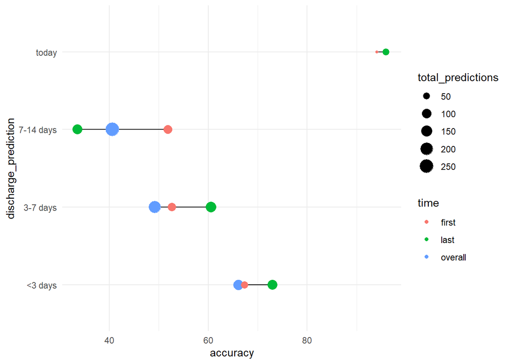

```r
bind_rows(
  pred_accuracy_rates,
  first_est_pred_accuracy_rates,
  last_est_pred_accuracy_rates
) %>%
  #mutate(discharge_prediction = fct_inorder(discharge_prediction)) %>% missing is the today data from the overall prediction
  ggplot(
    aes(x = accuracy, y = discharge_prediction, group = discharge_prediction)
  ) +
  geom_line() +
  geom_point(aes(color = time, size = total_predictions)) +
  theme_minimal()
```

Cleaning diagnosis information for later analysis.

```r
dx_total <- clean_data %>%
  group_by(visit_key) %>% #group by the patient IDs
  filter(est_number == 1) %>% #filter based off of first prediction
  ungroup() %>%
  select(dx1_icd10, dx2_icd10) %>%
  gather(key = "source", value = "dx") %>% #place diagnoses in one column
  add_count(short_dx = substr(dx, 1, 5)) %>%  #look only at first 4 characters in the ICD codes
  mutate(n = ifelse(short_dx == "Z38.0", 0, n)) %>% #Z38.0 is a diagnosis I'm uninterested in (it describes birth status), so I want this removed
  distinct(dx, n) %>% #maintaining granularity, but eliminating our short column
  print()
```

```
## # A tibble: 355 x 2
##    dx         n
##    <chr>  <dbl>
##  1 Z38.01     0
##  2 I27.20     5
##  3 Z38.00     0
##  4 Z38.31    31
##  5 P27.1     29
##  6 J96.22     6
##  7 K56.50     3
##  8 P27.8     22
##  9 J21.0     32
## 10 J96.01    27
## # ... with 345 more rows
```

```r
dx_1 <- dx_total %>% #new dataframe for primary diagnoses
  rename(dx1_icd10 = dx,
         dx1_n = n) #renaming the dx column for the primary diagnosis group to prepare to join it with the secondary diagnoses

dx_2 <- dx_total %>% #new dataframe for secondary diagnoses
  rename(dx2_icd10 = dx,
         dx2_n = n) #renaming the dx column for the secondary diagnosis group to prepare to join it with the primary diagnoses

clean_data <- clean_data %>%
  left_join(dx_1) %>% #join in dx_1 and dx_2 to clean data
  left_join(dx_2) %>%
  mutate(top_dx =
    case_when(dx1_n >= dx2_n ~ dx1_icd10,
              TRUE ~ dx2_icd10) #bring back the more common diagnosis to then be used in logistic regression
  )
```

Bivariate analysis to look at potential factors contributing to accuracy. First data was cleaned further and an additional dataframe examining the order of predictions was created.

```r
#new dataframe created for further analysis
rank_data <- clean_data %>%
  group_by(visit_key) %>% #group by the surrogate for patient IDs
  filter(discharge_prediction != "no date identified") %>%  #look at all patients who had a prediction time window (remove those without an identified date)
  mutate( #create a column that looks at when a prediction estimate was made and groups by first, last, other
    pred_order =
      case_when(est_number == max(est_number) ~ "last",
                est_number == 1 ~ "first",
                TRUE ~ "other"),
    total_est = max(est_number)
    ) %>%
  ungroup() %>%
  mutate(pred_order = as.factor(pred_order) %>%
           fct_relevel("last", "other", "first")) %>% #make into a factor and reorder them
  mutate(ett_status = as.factor(ett_status)) %>% #make ETT status into a factor for further analysis (it was recognized this was a significant variable in analysis and for visualization, I needed to ensure this was a factor)
  select(visit_key, accurate_prediction_ind, discharge_prediction, days_until_discharge, diff, gest_age_groups, sex, race, payor_group, pred_order, central_line_status, ett_status, iv_fluid_or_med_start_post_prediction, top_dx) #select variables

#bivariate analysis using a function and for loop
calc_p <- function(x) { #make a function to put into the for loop
   rslt <- summary(glm(accurate_prediction_ind ~ rank_data[[x]], data = rank_data, family = binomial())) #bivariate testing of each column against prediction accuracy
   data.frame( #make a dataframe that has the column name and p-values
     var = x,
     p_val = rslt$coefficients[2,4] #brings back p-value from the glm chart
   )
}

all_variables <- calc_p("discharge_prediction") #run the function looking at "discharge prediction" and assign to all_variables

for (i in names(rank_data %>% select(-c(visit_key, accurate_prediction_ind, discharge_prediction, diff, days_until_discharge)))){ #put function into the for loop, ensure that first column, diff, and days until discharge columns are removed
  all_variables <- bind_rows(all_variables, calc_p(i)) #bind the result from the above function
}

print(all_variables) #all variables to look at p-values
```

```
##                                      var        p_val
## 1                   discharge_prediction 3.218512e-03
## 2                        gest_age_groups 8.118644e-01
## 3                                    sex 6.178714e-01
## 4                                   race 9.794532e-01
## 5                            payor_group 9.401139e-01
## 6                             pred_order 6.678542e-05
## 7                    central_line_status 1.900313e-01
## 8                             ett_status 9.795772e-01
## 9  iv_fluid_or_med_start_post_prediction 7.985980e-02
## 10                                top_dx 1.000000e+00
```

```r
all_variables %>%
  filter(p_val <= .05) %>% #filter for significant variables with p<0.05
  arrange(p_val) #order values
```

```
##                    var        p_val
## 1           pred_order 6.678542e-05
## 2 discharge_prediction 3.218512e-03
```

```r
#discharge prediction choice and prediction order appear to be the only significant contributors to accuracy
```

Logistic regression of significant variables from bivariate analysis.

```r
summary(glm(accurate_prediction_ind ~ discharge_prediction + pred_order, data = rank_data, family = binomial))
```

```
##
## Call:
## glm(formula = accurate_prediction_ind ~ discharge_prediction +
##     pred_order, family = binomial, data = rank_data)
##
## Deviance Residuals:
##     Min       1Q   Median       3Q      Max
## -2.5293  -1.0725   0.2887   1.1696   1.4484
##
## Coefficients:
##                               Estimate Std. Error z value Pr(>|z|)
## (Intercept)                    0.68668    0.18814   3.650 0.000262 ***
## discharge_prediction3-7 days  -0.66834    0.24034  -2.781 0.005423 **
## discharge_prediction7-14 days -0.93858    0.24104  -3.894 9.86e-05 ***
## discharge_predictiontoday      2.47032    0.74594   3.312 0.000927 ***
## pred_orderother               -0.36573    0.22262  -1.643 0.100419
## pred_orderfirst                0.06829    0.35222   0.194 0.846279
## ---
## Signif. codes:  0 '***' 0.001 '**' 0.01 '*' 0.05 '.' 0.1 ' ' 1
##
## (Dispersion parameter for binomial family taken to be 1)
##
##     Null deviance: 846.29  on 611  degrees of freedom
## Residual deviance: 771.82  on 606  degrees of freedom
## AIC: 783.82
##
## Number of Fisher Scoring iterations: 5
```

```r
#in the logistic regression, only the discharge prediction appears to be significantly associated with accuracy

#let's look at first vs. last prediction accuracy by discharge prediction category
rank_data_first <- rank_data %>%
  filter(pred_order == "first")
summary(glm(accurate_prediction_ind ~ discharge_prediction + gest_age_groups + sex + race + payor_group + central_line_status + ett_status + iv_fluid_or_med_start_post_prediction + top_dx, data = rank_data_first, family = binomial))
```

```
##
## Call:
## glm(formula = accurate_prediction_ind ~ discharge_prediction +
##     gest_age_groups + sex + race + payor_group + central_line_status +
##     ett_status + iv_fluid_or_med_start_post_prediction + top_dx,
##     family = binomial, data = rank_data_first)
##
## Deviance Residuals:
##  [1]  0  0  0  0  0  0  0  0  0  0  0  0  0  0  0  0  0  0  0  0  0  0  0  0  0  0  0  0  0  0  0  0  0  0  0  0  0
##
## Coefficients: (3 not defined because of singularities)
##                                         Estimate Std. Error z value Pr(>|z|)
## (Intercept)                           -7.970e+01  3.471e+06       0        1
## discharge_prediction3-7 days           1.063e+01  1.508e+06       0        1
## discharge_prediction7-14 days          6.376e+01  2.413e+06       0        1
## gest_age_groups30-35 weeks             6.376e+01  1.250e+06       0        1
## gest_age_groups>35 weeks               7.438e+01  2.017e+06       0        1
## sexM                                  -3.188e+01  9.609e+05       0        1
## raceBlack or African American         -3.188e+01  1.061e+06       0        1
## raceMulti-Racial                      -2.125e+01  1.175e+06       0        1
## raceOther                             -2.125e+01  6.832e+05       0        1
## raceRefused                           -1.275e+02  8.781e+05       0        1
## raceWhite                             -1.063e+01  1.099e+06       0        1
## payor_groupGOVERNMENT                 -1.063e+01  3.769e+05       0        1
## central_line_status                    1.063e+01  1.516e+06       0        1
## ett_status2                            3.188e+01  5.136e+05       0        1
## iv_fluid_or_med_start_post_prediction -4.251e+01  1.075e+06       0        1
## top_dxI42.9                            1.488e+02  4.072e+06       0        1
## top_dxJ21.0                            3.188e+01  1.085e+06       0        1
## top_dxM26.09                           1.063e+01  1.166e+06       0        1
## top_dxP07.15                           2.125e+01  3.335e+06       0        1
## top_dxP07.16                           1.063e+01  9.503e+05       0        1
## top_dxP07.18                           2.125e+01  7.867e+05       0        1
## top_dxP07.39                          -7.438e+01  2.017e+06       0        1
## top_dxP22.0                           -3.188e+01  1.258e+06       0        1
## top_dxP25.1                           -6.376e+01  1.250e+06       0        1
## top_dxP28.5                            2.125e+01  5.136e+05       0        1
## top_dxP29.30                           2.447e-08  1.332e+06       0        1
## top_dxP39.3                            5.313e+01  8.723e+05       0        1
## top_dxP70.0                            2.125e+01  1.258e+06       0        1
## top_dxP70.4                            6.376e+01  3.301e+06       0        1
## top_dxP91.62                           3.188e+01  3.327e+06       0        1
## top_dxP91.63                           5.313e+01  3.264e+06       0        1
## top_dxP92.01                           9.564e+01  8.058e+05       0        1
## top_dxQ07.01                           2.125e+01  7.538e+05       0        1
## top_dxQ07.02                          -1.063e+01  1.902e+06       0        1
## top_dxQ21.2                            6.376e+01  5.873e+05       0        1
## top_dxQ21.3                           -6.376e+01  1.250e+06       0        1
## top_dxQ79.0                           -3.188e+01  1.196e+06       0        1
## top_dxQ80.9                                   NA         NA      NA       NA
## top_dxZ38.30                                  NA         NA      NA       NA
## top_dxZ38.31                                  NA         NA      NA       NA
##
## (Dispersion parameter for binomial family taken to be 1)
##
##     Null deviance: 5.1266e+01  on 36  degrees of freedom
## Residual deviance: 2.1466e-10  on  0  degrees of freedom
## AIC: 74
##
## Number of Fisher Scoring iterations: 25
```

```r
#no significant mediators of accuracy on first estimates

rank_data_last <- rank_data %>%
  filter(pred_order == "last")
summary(glm(accurate_prediction_ind ~ discharge_prediction + gest_age_groups + sex + race + payor_group + central_line_status + ett_status + iv_fluid_or_med_start_post_prediction + top_dx, data = rank_data_last, family = binomial))
```

```
##
## Call:
## glm(formula = accurate_prediction_ind ~ discharge_prediction +
##     gest_age_groups + sex + race + payor_group + central_line_status +
##     ett_status + iv_fluid_or_med_start_post_prediction + top_dx,
##     family = binomial, data = rank_data_last)
##
## Deviance Residuals:
##      Min        1Q    Median        3Q       Max
## -2.19646  -0.64764   0.00008   0.71559   2.02261
##
## Coefficients:
##                                         Estimate Std. Error z value Pr(>|z|)
## (Intercept)                              35.5270 11058.0582   0.003  0.99744
## discharge_prediction3-7 days             -1.0565     0.3905  -2.705  0.00682 **
## discharge_prediction7-14 days            -2.0948     0.4216  -4.969 6.74e-07 ***
## discharge_predictiontoday                 2.0536     0.8534   2.406  0.01612 *
## gest_age_groups25-30 weeks               -0.4598     0.9695  -0.474  0.63533
## gest_age_groups30-35 weeks                0.9976     0.9497   1.050  0.29355
## gest_age_groups>35 weeks                  0.7569     0.9037   0.838  0.40228
## sexM                                     -0.2954     0.2968  -0.995  0.31969
## raceAsian                               -19.1178 10754.0112  -0.002  0.99858
## raceBlack or African American           -18.6324 10754.0112  -0.002  0.99862
## raceIndian                              -19.2854 10754.0113  -0.002  0.99857
## raceMulti-Racial                        -18.5882 10754.0112  -0.002  0.99862
## raceOther                               -19.5765 10754.0112  -0.002  0.99855
## raceRefused                             -17.8678 10754.0113  -0.002  0.99867
## raceWhite                               -19.1117 10754.0112  -0.002  0.99858
## payor_groupCOMMERCIAL                    31.7403  3520.9838   0.009  0.99281
## payor_groupGOVERNMENT                    32.2012  3520.9838   0.009  0.99270
## central_line_status                      -0.1211     0.3067  -0.395  0.69301
## ett_status2                               0.2697     0.8819   0.306  0.75978
## iv_fluid_or_med_start_post_prediction    -0.2698     0.5209  -0.518  0.60444
## top_dxB37.7                             -28.0775 11605.0858  -0.002  0.99807
## top_dxC76.0                             -67.5876 11605.0857  -0.006  0.99535
## top_dxD48.0                             -30.3308 11605.0857  -0.003  0.99791
## top_dxE16.1                             -44.9909  4362.2496  -0.010  0.99177
## top_dxE43                               -48.6844  4362.2495  -0.011  0.99110
## top_dxE84.11                            -65.8717 11605.0857  -0.006  0.99547
## top_dxG00.2                             -28.0416 11605.0857  -0.002  0.99807
```

[output cut: 112 more lines]

```
## top_dxQ89.7                             -68.1832 11605.0857  -0.006  0.99531
## top_dxR78.81                            -29.2698 11605.0857  -0.003  0.99799
## top_dxZ11.59                            -31.8609 11605.0857  -0.003  0.99781
## top_dxZ38.30                            -46.7829  4362.2495  -0.011  0.99144
## top_dxZ38.31                            -46.7917  4362.2494  -0.011  0.99144
## ---
## Signif. codes:  0 '***' 0.001 '**' 0.01 '*' 0.05 '.' 0.1 ' ' 1
##
## (Dispersion parameter for binomial family taken to be 1)
##
##     Null deviance: 608.98  on 446  degrees of freedom
## Residual deviance: 345.08  on 303  degrees of freedom
## AIC: 633.08
##
## Number of Fisher Scoring iterations: 18
```

```r
#discharge prediction is the only significant mediator of accuracy at the time of the last prediction
```

Linear regression examining factors contributing to the degree of inaccuracy. First data was cleaned again.

```r
rank_data_correct <- rank_data %>%
  filter(accurate_prediction_ind == 0) %>%  #only look at estimates that were incorrect
  mutate(
    diff = (as.numeric(diff))
    )

summary(lm(diff ~ discharge_prediction + gest_age_groups + sex + race + payor_group + pred_order + central_line_status + ett_status + iv_fluid_or_med_start_post_prediction + top_dx, data = rank_data_correct))
```

```
##
## Call:
## lm(formula = diff ~ discharge_prediction + gest_age_groups +
##     sex + race + payor_group + pred_order + central_line_status +
##     ett_status + iv_fluid_or_med_start_post_prediction + top_dx,
##     data = rank_data_correct)
##
## Residuals:
##     Min      1Q  Median      3Q     Max
## -51.784  -5.405   0.000   3.762 125.106
##
## Coefficients: (1 not defined because of singularities)
##                                       Estimate Std. Error t value Pr(>|t|)
## (Intercept)                            21.6361    24.1241   0.897 0.370982
## discharge_prediction3-7 days           -5.1664     4.9270  -1.049 0.295768
## discharge_prediction7-14 days          -8.8984     4.7107  -1.889 0.060493 .
## discharge_predictiontoday              -7.0022    22.4411  -0.312 0.755380
## gest_age_groups25-30 weeks            -11.1896     8.3903  -1.334 0.184001
## gest_age_groups30-35 weeks             -6.9237     8.9610  -0.773 0.440737
## gest_age_groups>35 weeks              -17.9470     8.3480  -2.150 0.032894 *
## sexM                                    3.0490     3.3093   0.921 0.358102
## raceBlack or African American         -12.6328     8.8558  -1.426 0.155449
## raceIndian                            -24.9261    23.6115  -1.056 0.292523
## raceMulti-Racial                      -16.4082    11.8470  -1.385 0.167754
## raceOther                              -2.8397     8.8573  -0.321 0.748879
## raceRefused                           -20.0358    17.2265  -1.163 0.246329
## raceWhite                              -9.5672     8.5697  -1.116 0.265734
## payor_groupCOMMERCIAL                   6.4827    29.7144   0.218 0.827545
## payor_groupGOVERNMENT                   6.9955    29.2080   0.240 0.810985
## pred_orderother                        12.5549     3.6690   3.422 0.000769 ***
## pred_orderfirst                        16.0764     6.0738   2.647 0.008841 **
## central_line_status                     4.2673     3.2479   1.314 0.190555
## ett_status1                            38.4692    25.2501   1.524 0.129373
## ett_status2                            30.5122     6.9748   4.375 2.05e-05 ***
## iv_fluid_or_med_start_post_prediction   0.4360     4.1282   0.106 0.916006
## top_dxE16.1                            -7.9684    30.6553  -0.260 0.795210
## top_dxE43                              -0.6316    22.9148  -0.028 0.978041
## top_dxE84.11                           -2.6769    29.9399  -0.089 0.928856
## top_dxG93.89                           -3.4704    22.6371  -0.153 0.878327
## top_dxI74.3                            20.5128    28.9250   0.709 0.479131
```

[output cut: 72 more lines]

```
## top_dxQ79.0                            18.6527    21.9116   0.851 0.395745
## top_dxQ79.3                           -13.5301    29.8884  -0.453 0.651315
## top_dxQ80.9                            -8.6075    24.1865  -0.356 0.722346
## top_dxQ81.9                            12.7320    28.8436   0.441 0.659439
## top_dxQ87.0                             4.9902    24.1293   0.207 0.836389
## top_dxQ89.1                           -20.7569    30.8476  -0.673 0.501879
## top_dxQ89.7                            -0.6536    29.3308  -0.022 0.982246
## top_dxZ38.30                            9.6896    22.6860   0.427 0.669801
## top_dxZ38.31                           -5.5436    23.0850  -0.240 0.810496
## ---
## Signif. codes:  0 '***' 0.001 '**' 0.01 '*' 0.05 '.' 0.1 ' ' 1
##
## Residual standard error: 20.26 on 181 degrees of freedom
## Multiple R-squared:  0.5606, Adjusted R-squared:  0.3032
## F-statistic: 2.178 on 106 and 181 DF,  p-value: 2.035e-06
```

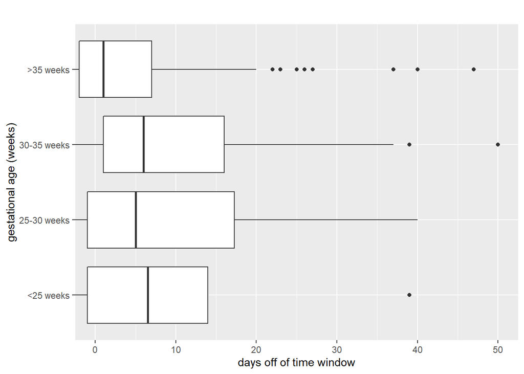

```r
#gestational age >35 weeks, prediction order, ETT status, and a diagnosis of stage 2 NEC  are associated with how off we are in our estimations

ggplot(rank_data_correct, aes(x = diff, y = gest_age_groups)) +
  geom_boxplot() +
  labs(title = "",
       y = "gestational age (weeks)",
       x = "days off of time window") +
  coord_cartesian(xlim = c(0,50)) #zoom in on the box plot to make it readable, recognizing that some of the outliers are lost
```